# Proyecto: Modelo de TFGb

MIGUEL ANGEL RODRIGUEZ FEREGRINO, 8vo Semestre, MICROBIOLOGIA

23 de abril del 2026

Vamos a trabajar con la Red de regulación producto del ligando TGF-beta (TGFb), esta red es vital durante la carcinogenesis ya que dependiendo del tipo de estimulo la respuesta peude variar, cumpliendo con un papel dual: promoción de malignidades o control del ciclo celular, entre otras muchas funciones supresoras de tumores. Por tanto la primer aproximación tiene esta forma:

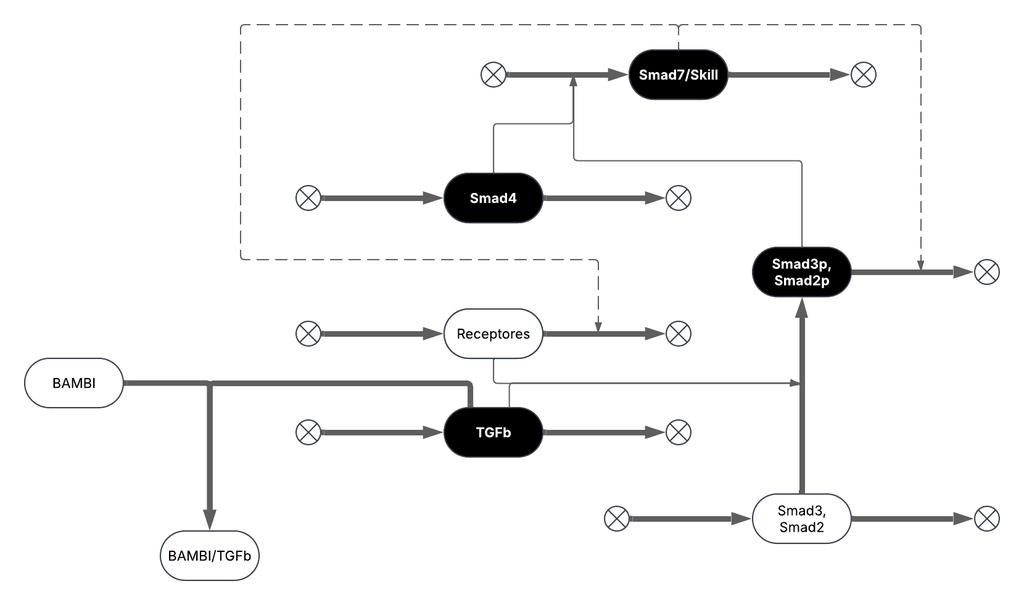

Red inicial propuesta

Sin embargo esta red es demasiado compleja como para analizar de forma optima por lo que vamos a reducirla: - Hay redundancia de señales, por lo que se pueden agrupar. - Algunas variables pueden cambiar a imputs del sistema, ya que no interactuan directamente con las demas. - Lo mas importante es conservar el ciclo de retroalimentacion negativa. - Nuestro objetivo es observar la activacion de forma prolongada de la via, ademas de la inactivacion rapida de la misma, cosa que nos llevaria a los dos fenotipos que queremos, por lo que el analisis de bifurcaciones es indispensable (por tanto trabajaremos con 2 variables)

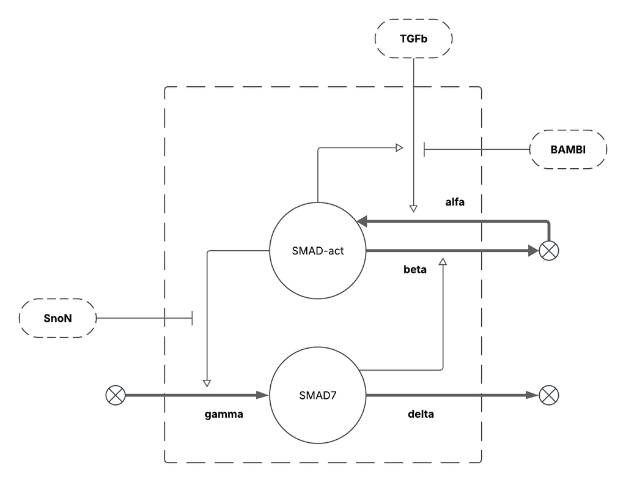

Las reacciones son:

- Reacción 1: Produccion y activacion de SMADactivo, mediado a su vez por la interaccion con TGFbeta y limitado por BAMBI, se representa con reaccion de HILL ya que puede ser una interaccion de varios componentes.
- Reacción 2: degradacion e inactivacion de SMADactivo, mediado por beta como indice basal y SMAD7 que contribuye segun una tasa mu1 a su inactivacion.
- Reacción 3: Activacion de SMAD7 que depende totalmente de SMADactivo
- Reacción 4: Degradacion e inactivacion de SMAD7, depende de una tasa delta basal y de SnoN segun una tasa mu2.

Un modelo seria:

$$\left\{\begin{array}{l}
\dot{SMAD_{act}}=\alpha + TGFb \cdot \frac{(SMAD_{act})^n}{BAMBI^n +
(SMAD_{act})^n}-SMAD_{act}(\beta + \mu_1 \cdot SMAD7) \\
\dot{SMAD7}=\gamma \cdot SMAD_{act} -SMAD7 (\mu_2 \cdot SnoN +
\delta)\\
\end{array}\right.$$

Realizando una simulacion inicial se observa:

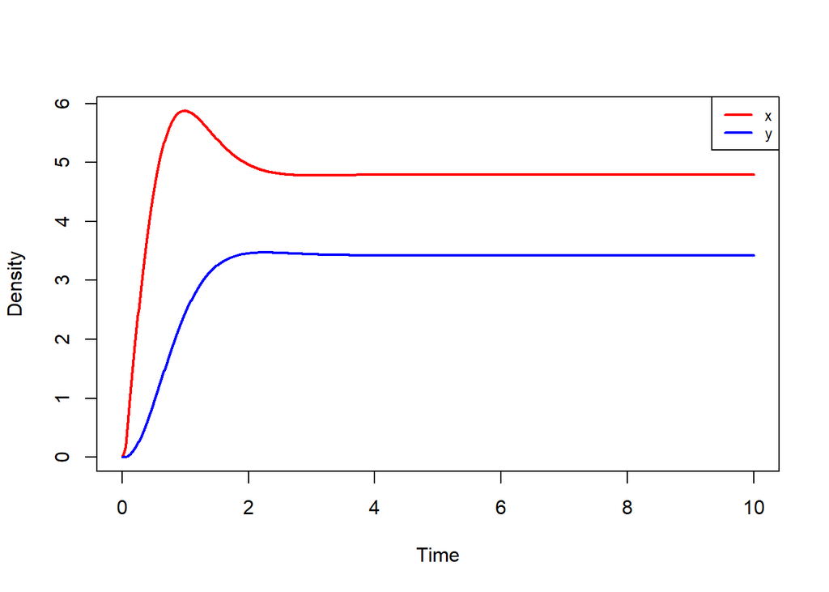

```
##        x        y
## 4.793545 3.423961
```

```r
par(mfrow = c(1,1))
model <- function(t, state, parms){
  with(as.list(c(state,parms)), {
    dx = alfa+TGFb*(x^n/(BAMBI^n + x^n))- x*(beta + (mu1*y))
    dy = gamma*x - y*((mu2*SnoN) + delta)
    return(list(c(dx, dy)))
  })
}
p <-  c(alfa = 3, TGFb = 10, BAMBI = 0.2,
        beta = 1, mu1 = 0.5, n = 6, gamma = 1, mu2 = 0.4, SnoN = 1, delta = 1)

s <- c(x=0,y=0)

run(tmax = 10, tstep = 0.01, state = s, parms = p, odes = model)
```

Que el sistema tiende a un equilibrio de ambas moleculas, lo cual tiene sentido en el caso de las estimulaciones constantes ya que a pesar de que hay retroaliemtacion negativa por y (SMAD7) sigue activa la via por lo que si hay arresto celular.

Ahora bien, si vemos las ceroclinas del sistema con estos parametros:

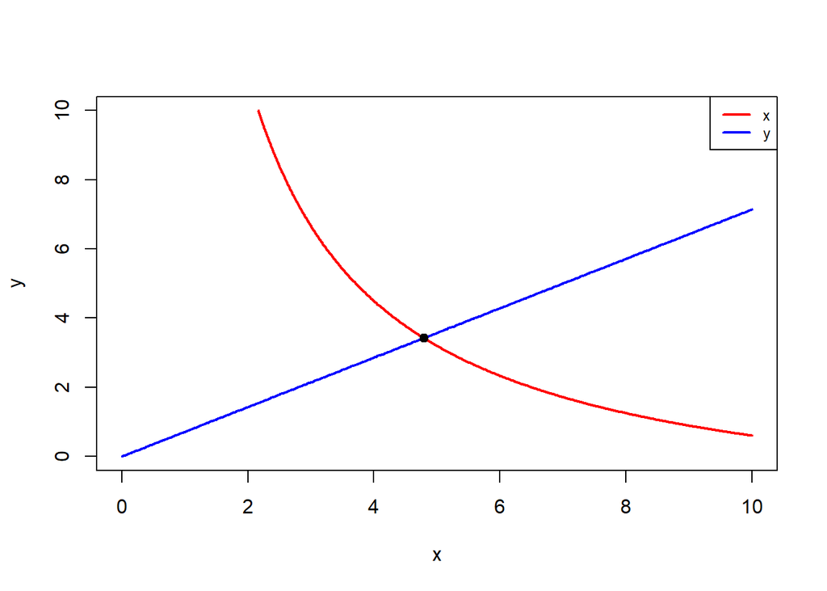

```
##        x        y
## 4.793545 3.423961
## Stable point, eigenvalues:  -2.05599+1.402301i -2.05599-1.402301i
```

```r
plane(xmax=10, ymax = 10)
mid <- newton(s,plot=T)
```

Se observa un unico punto de equilibrio.

```r
mid <- newton(s,plot=F)
```

```
##        x        y
## 4.793545 3.423961
## Stable point, eigenvalues:  -2.05599+1.402301i -2.05599-1.402301i
```

```r
low <- newton(c(x=10,y=0),plot=F)
```

```
##        x        y
## 4.793545 3.423961
## Stable point, eigenvalues:  -2.05599+1.402301i -2.05599-1.402301i
```

```r
hig <- newton(c(x=0,y=20),plot=F)
```

```
##        x        y
## 4.793545 3.423961
## Stable point, eigenvalues:  -2.05599+1.402301i -2.05599-1.402301i
```

```r
# Parametro beta
continue(state=low, parms = p, odes=model, x="beta", step=0.001,
         xmin=0,xmax=50,y="y", ymin=0, ymax=4)
```

```
## Starting at beta = 1 with:
##        x        y
## 4.793545 3.423961
```

```
## Turning point point at beta = 43.6543
## Turning point point at beta = 28.41523
```

```r
continue(state=mid,parms = p,odes=model, x="beta",  step=0.001,
         xmin=0, xmax=50,y="y", ymin=0, ymax=4, add = TRUE)
```

```
## Starting at beta = 1 with:
##        x        y
## 4.793545 3.423961
## Turning point point at beta = 43.6543
## Turning point point at beta = 28.41523
```

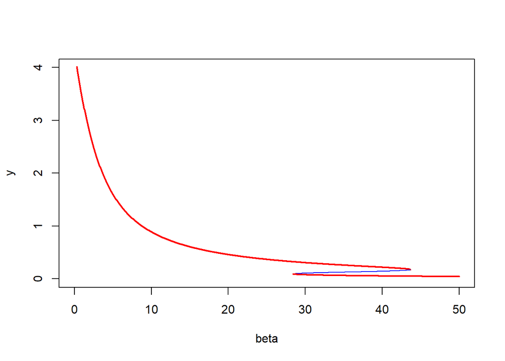

```
## Starting at beta = 1 with:
##        x        y
## 4.793545 3.423961
## Turning point point at beta = 43.6543
## Turning point point at beta = 28.41523
```

```r
continue(state=hig, parms = p, odes=model, x="beta", step=0.001,
         xmin=0, xmax=50,y="y", ymin=0, ymax=4, add = TRUE)
```

```r
continue(state=low, parms = p, odes=model, x="beta", step=0.001,
         xmin=0,xmax=50,y="x", ymin=0, ymax=5)
```

```
## Starting at beta = 1 with:
##        x        y
## 4.793545 3.423961
```

```
## Turning point point at beta = 43.6543
## Turning point point at beta = 28.41523
```

```r
continue(state=mid,parms = p,odes=model, x="beta",  step=0.001,
         xmin=0, xmax=50,y="x", ymin=0, ymax=5, add = TRUE)
```

```
## Starting at beta = 1 with:
##        x        y
## 4.793545 3.423961
## Turning point point at beta = 43.6543
## Turning point point at beta = 28.41523
```

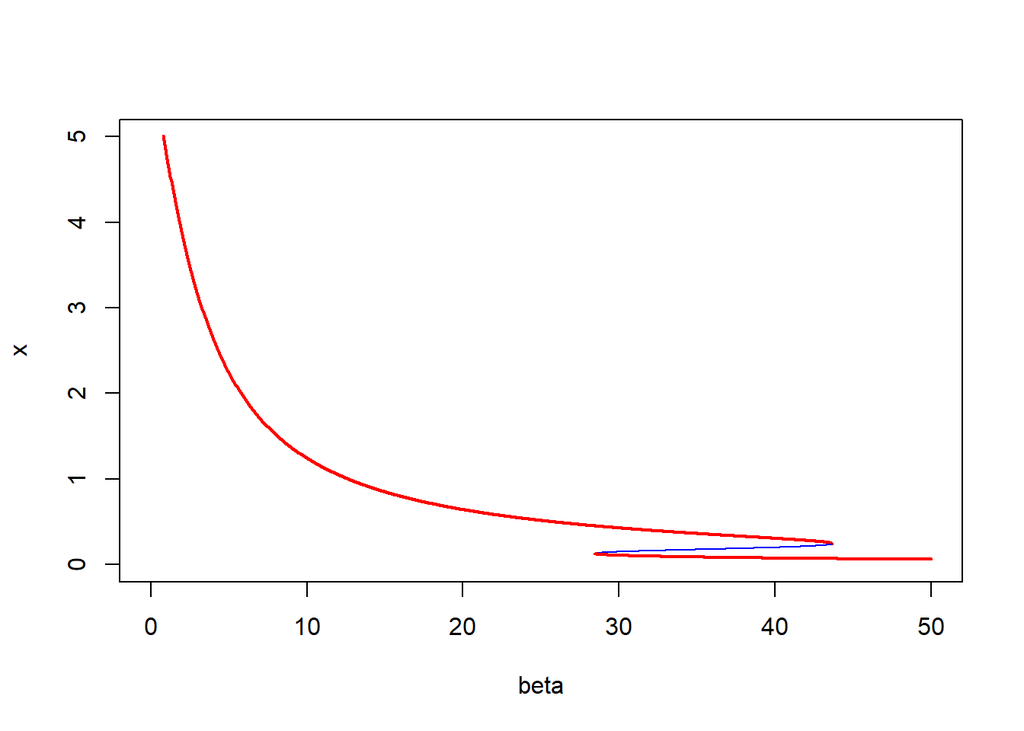

```
## Starting at beta = 1 with:
##        x        y
## 4.793545 3.423961
## Turning point point at beta = 43.6543
## Turning point point at beta = 28.41523
```

```r
continue(state=hig, parms = p, odes=model, x="beta", step=0.001,
         xmin=0, xmax=50,y="x", ymin=0, ymax=5, add = TRUE)
```

```r
p[4] <-  35
par(mfrow = c(1,1))
plane(xmax=0.5, ymax = 20)
mid <- newton(s,plot=T)
```

```
##          x          y
## 0.08764526 0.06260376
## Stable point, eigenvalues:  -30.24917 -1.401519
```

```r
low <- newton(c(x=0.2,y=1),plot=T)
```

```
##         x         y
## 0.1759943 0.1257102
## Unstable point, eigenvalues:  38.75868 -1.397809
```

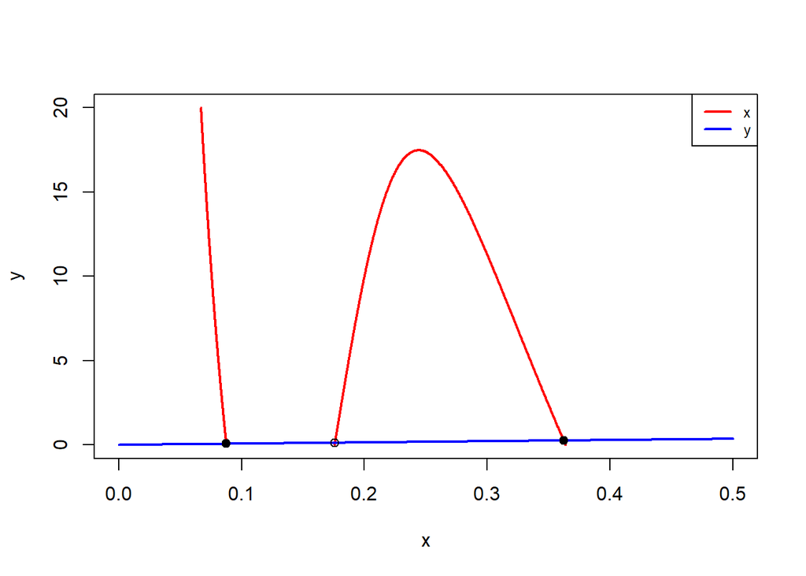

```
##         x         y
## 0.3622163 0.2587259
## Stable point, eigenvalues:  -30.6842 -1.406185
```

```r
hig <- newton(c(x=0.5,y=4),plot=T)
```

[figure not shown]

```r
## 3 puntos de equilibrio



ini_1 <- c(x=0,y=0)
ini_2 <- c(x=0.5,y=4)

par(mfrow = c(3,2))
for (i in 1:3) {
  a <- c(5,0.5,0.5)
  b<- c(0.1, 35, 50)
  beta2 <- b[i]
  out1 <- ode(y = ini_1, times = seq(from = 0, to = 10, by = 0.01), func = model, parms = p)

  plot(out1[,1], out1[,2],type = "l", ylim=c(0,a[i]),
       col="red", xlab = "Time", ylab = "X(t)",
       main = paste("beta=", toString(beta2), sep=" "))

  out2 <- ode(y = ini_2, times = seq(from = 0, to = 10, by = 0.01), func = model, parms = p)
  lines(out2[,1], out2[,2],type = "l", col="blue")
  legend=c(paste("I.C.=", toString(ini_1), sep=" "), paste("I.C.=", toString(ini_2), sep=" "))

  poli.flowField <- flowField(
    model, xlim = c(0, a[i]), ylim = c(0, 10),
    parameters = p, points = 20, add = FALSE)
  poli.trajectory <- trajectory(
    model, y0 = ini_1, tlim = c(0,20),
    parameters = p, col = "blue")
  poli.trajectory <- trajectory(
    model, y0 = ini_2, tlim = c(0,20),
    parameters = p, col = "red")
}
```

[output not shown]

```
##        x        y
## 5.894865 4.210618
## Stable point, eigenvalues:  -1.802655+1.668922i -1.802655-1.668922i
##        x        y
## 5.894865 4.210618
## Stable point, eigenvalues:  -1.802655+1.668922i -1.802655-1.668922i
##        x        y
## 5.894866 4.210619
## Stable point, eigenvalues:  -1.802655+1.668922i -1.802655-1.668922i
```

```
##          x          y
## 0.08764526 0.06260376
## Stable point, eigenvalues:  -30.24917 -1.401519
##         x         y
## 0.1759943 0.1257102
## Unstable point, eigenvalues:  38.75868 -1.397809
##         x         y
## 0.3622163 0.2587259
## Stable point, eigenvalues:  -30.6842 -1.406185
```

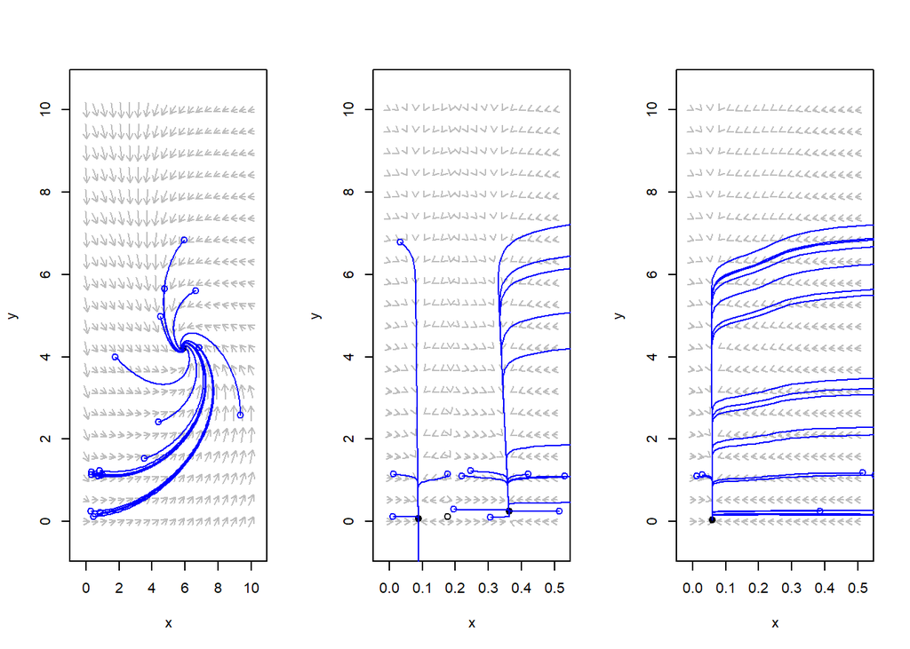

```
##          x          y
## 0.06012166 0.04294404
## Stable point, eigenvalues:  -49.28551 -1.400628
##          x          y
## 0.06012166 0.04294404
## Stable point, eigenvalues:  -49.28551 -1.400628
##          x          y
## 0.06012166 0.04294404
## Stable point, eigenvalues:  -49.28551 -1.400628
```

```r
## asi se observan las soluciones del sistema en los 3 dominios del parametro


par(mfrow = c(1,3))
for (i in 1:3) {
  a <- c(10,0.5,0.5)
  b<- c(0.1, 35, 50)
  beta2 <- b[i]
  p[4] <-  beta2
  flowField(model, xlim = c(0, a[i]), ylim = c(0, 10), parameters = p, points = 20, add = FALSE)
  s <- c(x=0,y=0)
  mid <- newton(s,plot=T)
  low <- newton(c(x=0.2,y=1),plot=T)
  hig <- newton(c(x=0.5,y=4),plot=T)

  for (ii in seq(1,20,1) ){
    r1=runif(1); r2=runif(1); r3=runif(1);

    if (r1<0.5){
      ini = c(as.numeric(r2<0.5) + rnorm(1,sample(1:7)), r3 + rnorm(1,sample(1:7)))
    } else {
      ini = c(r3, as.numeric(r2<0.5) + 0.1^r1)
    }

    trajectory(model, y0 = ini, tlim = c(0,20), parameters = p, col = "blue")
  }
}
```

```r
par(mfrow = c(1,1))
p[4] <-  1

## Asi se observan los espacios vectoriales de los tres dominios
```

```r
mid <- newton(s,plot=F)
```

```
##        x        y
## 4.793545 3.423961
## Stable point, eigenvalues:  -2.05599+1.402301i -2.05599-1.402301i
```

```r
low <- newton(c(x=10,y=0),plot=F)
```

```
##        x        y
## 4.793545 3.423961
## Stable point, eigenvalues:  -2.05599+1.402301i -2.05599-1.402301i
```

```r
hig <- newton(c(x=0,y=20),plot=F)
```

```
##        x        y
## 4.793545 3.423961
## Stable point, eigenvalues:  -2.05599+1.402301i -2.05599-1.402301i
```

```r
# parametro BAMBI
continue(state=low, parms = p, odes=model, x="BAMBI", step=0.001,
         xmin=0,xmax=10,y="y", ymin=0, ymax=6)
```

```
## Starting at BAMBI = 0.2 with:
##        x        y
## 4.793545 3.423961
```

```
## Turning point point at BAMBI = 3.562578
## Turning point point at BAMBI = 3.210703
```

```r
continue(state=mid,parms = p,odes=model, x="BAMBI",  step=0.001,
         xmin=0, xmax=10,y="y", ymin=0, ymax=6, add = TRUE)
```

```
## Starting at BAMBI = 0.2 with:
##        x        y
## 4.793545 3.423961
## Turning point point at BAMBI = 3.562578
## Turning point point at BAMBI = 3.210703
```

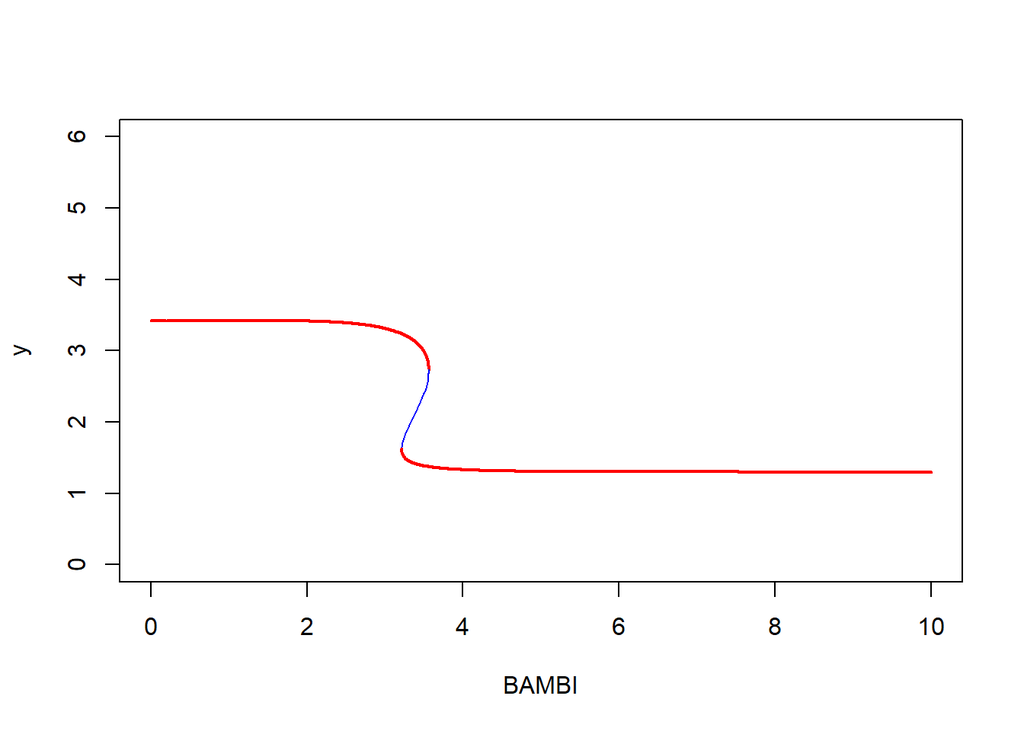

```
## Starting at BAMBI = 0.2 with:
##        x        y
## 4.793545 3.423961
## Turning point point at BAMBI = 3.562578
## Turning point point at BAMBI = 3.210703
```

```r
continue(state=hig, parms = p, odes=model, x="BAMBI", step=0.001,
         xmin=0, xmax=10,y="y", ymin=0, ymax=6, add = TRUE)
```

```r
continue(state=low, parms = p, odes=model, x="BAMBI", step=0.001,
         xmin=0,xmax=10,y="x", ymin=0, ymax=6)
```

```
## Starting at BAMBI = 0.2 with:
##        x        y
## 4.793545 3.423961
```

```
## Turning point point at BAMBI = 3.562578
## Turning point point at BAMBI = 3.210703
```

```r
continue(state=mid,parms = p,odes=model, x="BAMBI",  step=0.001,
         xmin=0, xmax=10,y="x", ymin=0, ymax=6, add = TRUE)
```

```
## Starting at BAMBI = 0.2 with:
##        x        y
## 4.793545 3.423961
## Turning point point at BAMBI = 3.562578
## Turning point point at BAMBI = 3.210703
```

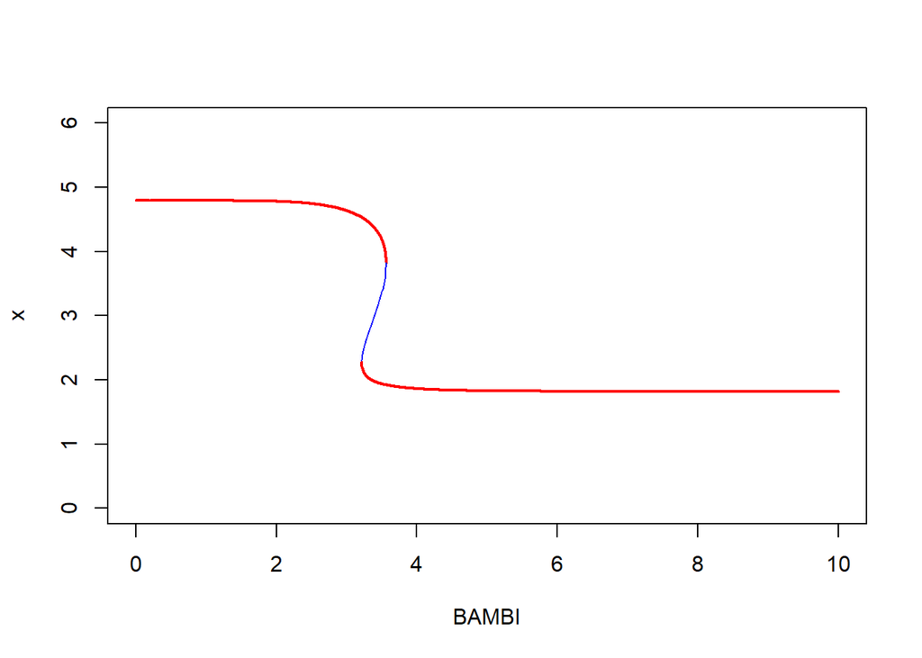

```
## Starting at BAMBI = 0.2 with:
##        x        y
## 4.793545 3.423961
## Turning point point at BAMBI = 3.562578
## Turning point point at BAMBI = 3.210703
```

```r
continue(state=hig, parms = p, odes=model, x="BAMBI", step=0.001,
         xmin=0, xmax=10,y="x", ymin=0, ymax=6, add = TRUE)
```

Con los parametros aqui propuestos, cuando BAMBI tiene un valor entre 3.2 y 3.6 tenemos biestabilidad, que se observa:

```r
p[3] <- 3.3
par(mfrow = c(1,1))
plane(xmax=10, ymax = 4)
mid <- newton(s,plot=T)
```

```
##        x        y
## 2.696017 1.925726
## Unstable point, eigenvalues:  1.504697 -0.9359211
```

```r
low <- newton(c(x=2,y=1),plot=T)
```

```
##        x        y
## 2.042339 1.458813
## Stable point, eigenvalues:  -0.8247746+0.830834i -0.8247746-0.830834i
```

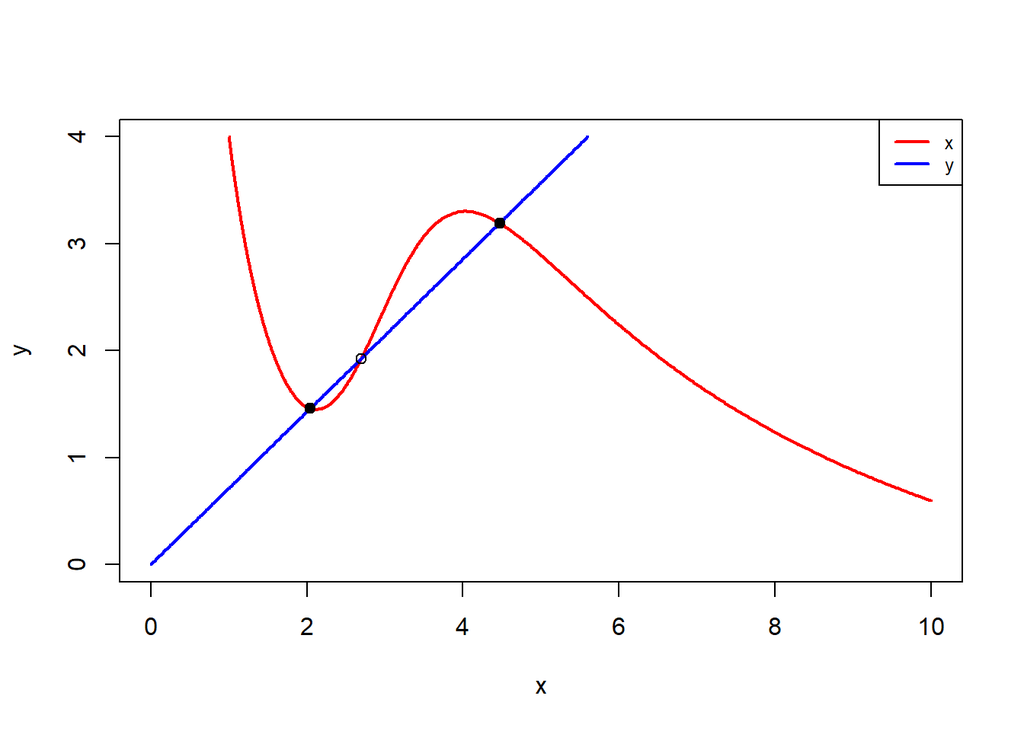

```
##        x        y
## 4.470225 3.193018
## Stable point, eigenvalues:  -1.193616+1.480715i -1.193616-1.480715i
```

```r
hig <- newton(c(x=5,y=4),plot=T)
```

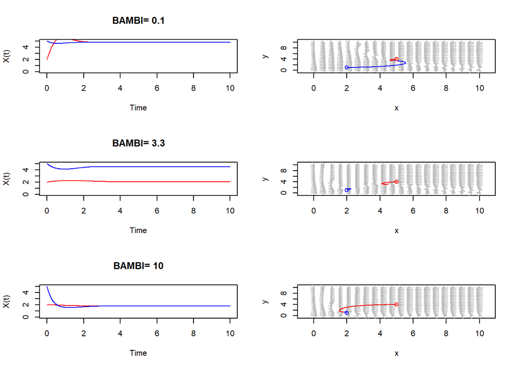

```r
## 3 puntos de equilibrio


ini_1 <- c(x=2,y=1)
ini_2 <- c(x=5,y=4)

par(mfrow = c(3,2))
for (BAMBI2 in c(0.1, 3.3, 10)) {
  p[3] <-  BAMBI2
  out1 <- ode(y = ini_1, times = seq(from = 0, to = 10, by = 0.01), func = model, parms = p)

  plot(out1[,1], out1[,2],type = "l", ylim=c(0,5),
       col="red", xlab = "Time", ylab = "X(t)",
       main = paste("BAMBI=", toString(BAMBI2), sep=" "))

  out2 <- ode(y = ini_2, times = seq(from = 0, to = 10, by = 0.01), func = model, parms = p)
  lines(out2[,1], out2[,2],type = "l", col="blue")
  legend=c(paste("I.C.=", toString(ini_1), sep=" "), paste("I.C.=", toString(ini_2), sep=" "))

  poli.flowField <- flowField(
    model, xlim = c(0, 10), ylim = c(0, 10),
    parameters = p, points = 20, add = FALSE)
  poli.trajectory <- trajectory(
    model, y0 = ini_1, tlim = c(0,20),
    parameters = p, col = "blue")
  poli.trajectory <- trajectory(
    model, y0 = ini_2, tlim = c(0,20),
    parameters = p, col = "red")
}
```

```
##        x        y
## 4.793545 3.423961
## Stable point, eigenvalues:  -2.05599+1.402301i -2.05599-1.402301i
##        x        y
## 4.793545 3.423961
## Stable point, eigenvalues:  -2.05599+1.402301i -2.05599-1.402301i
##        x        y
## 4.793545 3.423961
## Stable point, eigenvalues:  -2.05599+1.402301i -2.05599-1.402301i
```

```
##        x        y
## 2.696017 1.925726
## Unstable point, eigenvalues:  1.504697 -0.9359211
##        x        y
## 2.042339 1.458813
## Stable point, eigenvalues:  -0.8247746+0.830834i -0.8247746-0.830834i
##        x        y
## 4.470225 3.193018
## Stable point, eigenvalues:  -1.193616+1.480715i -1.193616-1.480715i
```

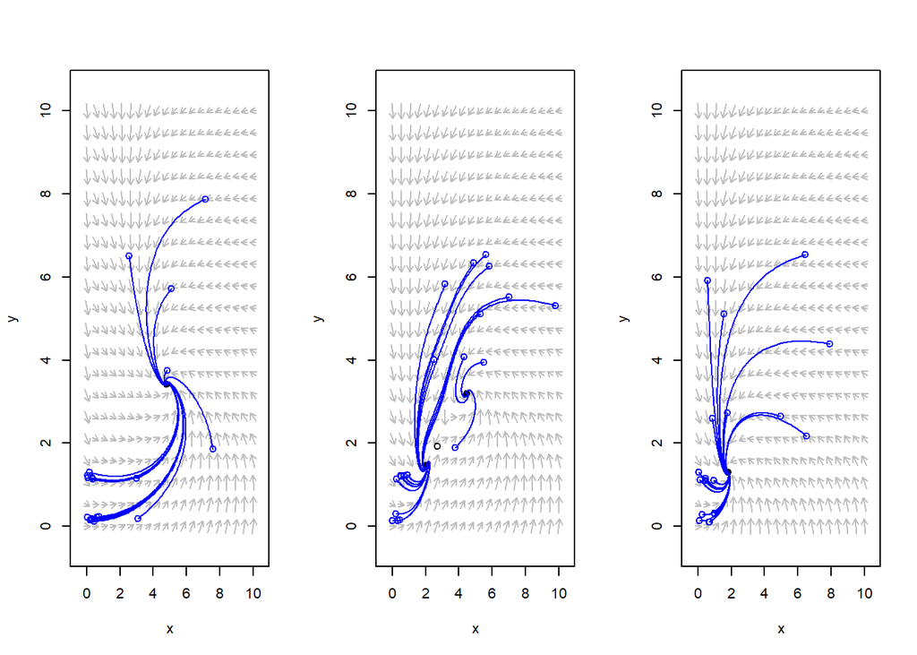

```
##        x        y
## 1.818853 1.299181
## Stable point, eigenvalues:  -1.524198+0.9455164i -1.524198-0.9455164i
##        x        y
## 1.818853 1.299181
## Stable point, eigenvalues:  -1.524198+0.9455164i -1.524198-0.9455164i
##        x        y
## 1.818853 1.299181
## Stable point, eigenvalues:  -1.524198+0.9455165i -1.524198-0.9455165i
```

```r
## asi se observan las soluciones del sistema en los 3 dominios del parametro


par(mfrow = c(1,3))
for (BAMBI2 in c(0.1, 3.3, 10)){
  p[3] <-  BAMBI2
  flowField(model, xlim = c(0, 10), ylim = c(0, 10), parameters = p, points = 20, add = FALSE)
  s <- c(x=0,y=0)
  mid <- newton(s,plot=T)
  low <- newton(c(x=2,y=1),plot=T)
  hig <- newton(c(x=5,y=4),plot=T)

  for (ii in seq(1,20,1) ){
    r1=runif(1); r2=runif(1); r3=runif(1);

    if (r1<0.5){
      ini = c(as.numeric(r2<0.5) + rnorm(1,sample(1:7)), r3 + rnorm(1,sample(1:7)))
    } else {
      ini = c(r3, as.numeric(r2<0.5) + 0.1^r1)
    }

    trajectory(model, y0 = ini, tlim = c(0,20), parameters = p, col = "blue")
  }
}
```

```r
par(mfrow = c(1,1))
p[3] <-  0.2

## Asi se observan los espacios vectoriales de los tres dominios
```

En conclusion, tiene sentido que BAMBI sea un parametro de bifurcacion, ya que este domina la capacidad de TFGb de estimular la activacion, por lo que en celulas cancerigenas este puede tener hiperactividad y suprimir la via, llevando a que aun ante estimulos constantes de TFGb se interrumpa la señal de activacion. Por otro lado el parametro beta representa la degradacion/inactivacion basal de las SMAD, por lo que si tenemos una mutacion que lleve a alta degradacion de igual forma podemos tener una inactivacion temprana de la via.

A este modelo le hace falta introducir justo la dependencia de TFGb de la activacion de su propia via, como se veria si este fuera dinamico en el tiempo y ademas incluir que BAMBI tambien es producto de la activacion de la via, no esta activo siempre.